# Assignment 2:

**Question 3.2.1.** An investment analyst has tracked a certain bluechip stock for the past six months and found that on any given day, it either goes up a point or goes down a point. Furthermore, it went up on 25% of the days and down on 75%. What is the probability that at the close of trading four days from now, the price of the stock will be the same as it is today? Assume that the daily fluctuations are independent events.

**Question 3.2.16.** Listed in the following table is the length distribution of World Series competition for the 58 series from 1950 to 2008 (there was no series in 1994).

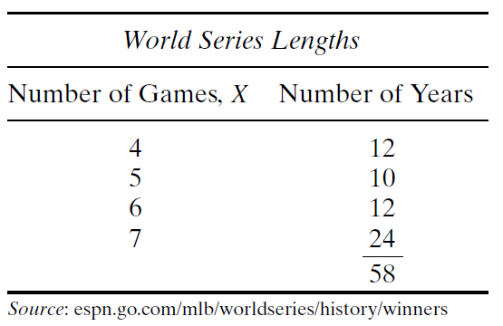

Assuming that each World Series game is an independent event and that the probability of either team's winning any particular contest is 0.5, find the probability of each series length. How well does the model fit the data? (Compute the "expected" frequencies, that is, multiply the probability of a given-length series times 58).

Plot a graph comparing the "expected" frequencies versus the data

**Question 3.2.27.** A display case contains thirty-five gems, of which ten are real diamonds and twenty-five are fake diamonds. A burglar removes four gems at random, one at a time and without replacement. What is the probability that the last gem she steals is the second real diamond in the set of four?

Then, suppose that the burglar removes 10 diamonds instead. How many real diamonds is she more likely to steal? Plot the distribution function.